# Modeling and Analyzing COVID-19 Cases

## Probability and Estimators

**By**: Victor Cornejo

## Introduction

In this project, I investigated a dataset that contained information about COVID-19 cases in the United States, vaccination rates, and various other metadata that assisted me in modeling various aspects of COVID-19.

Through this project I demonstrate my experience with:

- Bootstrap sampling
- Bias-variance tradeoff and decomposition
- Multicollinearity in features

```python
import numpy as np
import pandas as pd
import sklearn.linear_model as lm
from sklearn.model_selection import train_test_split

import matplotlib.pyplot as plt
import seaborn as sns
from IPython.display import Markdown

import scipy.stats

import warnings
warnings.filterwarnings("ignore")
```

## Exploratory Data Analysis

To begin, I performed some initial exploratory data analysis to examine and visualize potential trends in a COVID-19 dataset.

```python
covid_data = pd.read_csv('data/covid_data.csv')
covid_data.head(5)
```

|  | UID | iso2 | iso3 | code3 | FIPS | Admin2 | Province_State | Country_Region | Lat | Long_ | ... | POPESTIMATE2018 | POPESTIMATE2019 | POPESTIMATE042020 | POPESTIMATE2020 | COUNTYFP | NEVER | RARELY | SOMETIMES | FREQUENTLY | ALWAYS |
| --- | --- | --- | --- | --- | --- | --- | --- | --- | --- | --- | --- | --- | --- | --- | --- | --- | --- | --- | --- | --- | --- |
| 0 | 84001001 | US | USA | 840 | 1001 | Autauga | Alabama | US | 32.539527 | -86.644082 | ... | 55533 | 55769 | 56130 | 56145 | 1001 | 0.053 | 0.074 | 0.134 | 0.295 | 0.444 |
| 1 | 84001003 | US | USA | 840 | 1003 | Baldwin | Alabama | US | 30.727750 | -87.722071 | ... | 218071 | 223565 | 227989 | 229287 | 1003 | 0.083 | 0.059 | 0.098 | 0.323 | 0.436 |
| 2 | 84001005 | US | USA | 840 | 1005 | Barbour | Alabama | US | 31.868263 | -85.387129 | ... | 24887 | 24657 | 24652 | 24589 | 1005 | 0.067 | 0.121 | 0.120 | 0.201 | 0.491 |
| 3 | 84001007 | US | USA | 840 | 1007 | Bibb | Alabama | US | 32.996421 | -87.125115 | ... | 22300 | 22313 | 22199 | 22136 | 1007 | 0.020 | 0.034 | 0.096 | 0.278 | 0.572 |
| 4 | 84001009 | US | USA | 840 | 1009 | Blount | Alabama | US | 33.982109 | -86.567906 | ... | 57770 | 57840 | 57932 | 57879 | 1009 | 0.053 | 0.114 | 0.180 | 0.194 | 0.459 |

5 rows × 638 columns

The data are at county granularity; each row corresponded to COVID-19 data from one U.S. county. Here are some highlights and data sources:

- The first few columns encode county and state data; for example, check out the [FIPS](https://transition.fcc.gov/oet/info/maps/census/fips/fips.txt) numeric encoding for U.S. counties.
- The next 600 columns record daily COVID-19 cases in the county for the date range 1/22/2020 to 9/12/2021. COVID-19 case data are from CSSE at Johns Hopkins University [GitHub](https://github.com/CSSEGISandData/COVID-19/blob/master/csse_covid_19_data/csse_covid_19_time_series/time_series_covid19_confirmed_US.csv).
- The next few columns include county populations from [U.S. census data](https://www2.census.gov/programs-surveys/popest/datasets/2010-2020/counties/totals/co-est2020.csv), the latest of which is 2020.
- The last 5 columns record mask usage survey data on a 5-point scale from `NEVER` to `ALWAYS`. Data are collected in July 2020 from the New York Times [GitHub](https://github.com/nytimes/covid-19-data/blob/master/mask-use/mask-use-by-county.csv). Each column represents the proportion of population in that county who never/rarely/sometimes/frequently/always wear masks. Note, for a particular row, the numbers in those five columns sum up to $1$.

```python
covid_data.describe()
```

|  | UID | code3 | FIPS | Lat | Long_ | 1/22/20 | 1/23/20 | 1/24/20 | 1/25/20 | 1/26/20 | ... | POPESTIMATE2018 | POPESTIMATE2019 | POPESTIMATE042020 | POPESTIMATE2020 | COUNTYFP | NEVER | RARELY | SOMETIMES | FREQUENTLY | ALWAYS |
| --- | --- | --- | --- | --- | --- | --- | --- | --- | --- | --- | --- | --- | --- | --- | --- | --- | --- | --- | --- | --- | --- |
| count | 3.141000e+03 | 3141.0 | 3141.000000 | 3141.000000 | 3141.000000 | 3141.000000 | 3141.000000 | 3141.000000 | 3141.000000 | 3141.000000 | ... | 3.141000e+03 | 3.141000e+03 | 3.141000e+03 | 3.141000e+03 | 3141.000000 | 3141.000000 | 3141.000000 | 3141.000000 | 3141.000000 | 3141.000000 |
| mean | 8.403039e+07 | 840.0 | 30392.602674 | 38.448156 | -92.272006 | 0.000318 | 0.000318 | 0.000637 | 0.000637 | 0.001592 | ... | 1.040525e+05 | 1.045274e+05 | 1.048677e+05 | 1.048949e+05 | 30392.602674 | 0.079952 | 0.082929 | 0.121340 | 0.207728 | 0.508044 |
| std | 1.515661e+04 | 0.0 | 15156.613190 | 5.292540 | 12.909318 | 0.017843 | 0.017843 | 0.025230 | 0.025230 | 0.039873 | ... | 3.326200e+05 | 3.332156e+05 | 3.335848e+05 | 3.333719e+05 | 15156.613190 | 0.058543 | 0.055469 | 0.058007 | 0.063581 | 0.152190 |
| min | 8.400100e+07 | 840.0 | 1001.000000 | 19.601212 | -174.159600 | 0.000000 | 0.000000 | 0.000000 | 0.000000 | 0.000000 | ... | 8.700000e+01 | 8.700000e+01 | 9.000000e+01 | 8.700000e+01 | 1001.000000 | 0.000000 | 0.000000 | 0.001000 | 0.029000 | 0.115000 |
| 25% | 8.401818e+07 | 840.0 | 18179.000000 | 34.693167 | -98.218207 | 0.000000 | 0.000000 | 0.000000 | 0.000000 | 0.000000 | ... | 1.096300e+04 | 1.093600e+04 | 1.091900e+04 | 1.092100e+04 | 18179.000000 | 0.034000 | 0.040000 | 0.079000 | 0.164000 | 0.393000 |
| 50% | 8.402918e+07 | 840.0 | 29177.000000 | 38.373019 | -90.396561 | 0.000000 | 0.000000 | 0.000000 | 0.000000 | 0.000000 | ... | 2.583700e+04 | 2.573500e+04 | 2.570100e+04 | 2.565800e+04 | 29177.000000 | 0.068000 | 0.073000 | 0.115000 | 0.204000 | 0.497000 |
| 75% | 8.404508e+07 | 840.0 | 45081.000000 | 41.802830 | -83.436796 | 0.000000 | 0.000000 | 0.000000 | 0.000000 | 0.000000 | ... | 6.813600e+04 | 6.828200e+04 | 6.822000e+04 | 6.824100e+04 | 45081.000000 | 0.113000 | 0.115000 | 0.156000 | 0.247000 | 0.613000 |
| max | 8.405604e+07 | 840.0 | 56045.000000 | 69.314792 | -67.628135 | 1.000000 | 1.000000 | 1.000000 | 1.000000 | 1.000000 | ... | 1.006153e+07 | 1.001160e+07 | 9.968969e+06 | 9.943046e+06 | 56045.000000 | 0.432000 | 0.384000 | 0.422000 | 0.549000 | 0.889000 |

8 rows × 630 columns

In this project, I made use of linear regression to predict **the number of COVID-19 cases per capita on September 12th, 2021**. I defined a column `'9/12/2021_cpc'` in `covid_data` corresponding to the number of cases per capita on September 12th, 2021.

Note that I **always** used the `'POPESTIMATE2020'` as the population of each county.

```python
covid_data.head()
```

|  | UID | iso2 | iso3 | code3 | FIPS | Admin2 | Province_State | Country_Region | Lat | Long_ | ... | POPESTIMATE2018 | POPESTIMATE2019 | POPESTIMATE042020 | POPESTIMATE2020 | COUNTYFP | NEVER | RARELY | SOMETIMES | FREQUENTLY | ALWAYS |
| --- | --- | --- | --- | --- | --- | --- | --- | --- | --- | --- | --- | --- | --- | --- | --- | --- | --- | --- | --- | --- | --- |
| 0 | 84001001 | US | USA | 840 | 1001 | Autauga | Alabama | US | 32.539527 | -86.644082 | ... | 55533 | 55769 | 56130 | 56145 | 1001 | 0.053 | 0.074 | 0.134 | 0.295 | 0.444 |
| 1 | 84001003 | US | USA | 840 | 1003 | Baldwin | Alabama | US | 30.727750 | -87.722071 | ... | 218071 | 223565 | 227989 | 229287 | 1003 | 0.083 | 0.059 | 0.098 | 0.323 | 0.436 |
| 2 | 84001005 | US | USA | 840 | 1005 | Barbour | Alabama | US | 31.868263 | -85.387129 | ... | 24887 | 24657 | 24652 | 24589 | 1005 | 0.067 | 0.121 | 0.120 | 0.201 | 0.491 |
| 3 | 84001007 | US | USA | 840 | 1007 | Bibb | Alabama | US | 32.996421 | -87.125115 | ... | 22300 | 22313 | 22199 | 22136 | 1007 | 0.020 | 0.034 | 0.096 | 0.278 | 0.572 |
| 4 | 84001009 | US | USA | 840 | 1009 | Blount | Alabama | US | 33.982109 | -86.567906 | ... | 57770 | 57840 | 57932 | 57879 | 1009 | 0.053 | 0.114 | 0.180 | 0.194 | 0.459 |

5 rows × 638 columns

```python
covid_data['9/12/2021_cpc'] = covid_data['9/12/21'] / covid_data['POPESTIMATE2020']
covid_data.head()
```

|  | UID | iso2 | iso3 | code3 | FIPS | Admin2 | Province_State | Country_Region | Lat | Long_ | ... | POPESTIMATE2019 | POPESTIMATE042020 | POPESTIMATE2020 | COUNTYFP | NEVER | RARELY | SOMETIMES | FREQUENTLY | ALWAYS | 9/12/2021_cpc |
| --- | --- | --- | --- | --- | --- | --- | --- | --- | --- | --- | --- | --- | --- | --- | --- | --- | --- | --- | --- | --- | --- |
| 0 | 84001001 | US | USA | 840 | 1001 | Autauga | Alabama | US | 32.539527 | -86.644082 | ... | 55769 | 56130 | 56145 | 1001 | 0.053 | 0.074 | 0.134 | 0.295 | 0.444 | 0.165411 |
| 1 | 84001003 | US | USA | 840 | 1003 | Baldwin | Alabama | US | 30.727750 | -87.722071 | ... | 223565 | 227989 | 229287 | 1003 | 0.083 | 0.059 | 0.098 | 0.323 | 0.436 | 0.152429 |
| 2 | 84001005 | US | USA | 840 | 1005 | Barbour | Alabama | US | 31.868263 | -85.387129 | ... | 24657 | 24652 | 24589 | 1005 | 0.067 | 0.121 | 0.120 | 0.201 | 0.491 | 0.134003 |
| 3 | 84001007 | US | USA | 840 | 1007 | Bibb | Alabama | US | 32.996421 | -87.125115 | ... | 22313 | 22199 | 22136 | 1007 | 0.020 | 0.034 | 0.096 | 0.278 | 0.572 | 0.171440 |
| 4 | 84001009 | US | USA | 840 | 1009 | Blount | Alabama | US | 33.982109 | -86.567906 | ... | 57840 | 57932 | 57879 | 1009 | 0.053 | 0.114 | 0.180 | 0.194 | 0.459 | 0.158538 |

5 rows × 639 columns

I then assigned `mask_data` that has six columns from the original `covid_data` table: the five mask usage columns and the `9/12/2021_cpc` column.

```python
mask_data = covid_data[['NEVER', 'RARELY', 'SOMETIMES', 'FREQUENTLY', 'ALWAYS', '9/12/2021_cpc']].copy()
mask_data
```

|  | NEVER | RARELY | SOMETIMES | FREQUENTLY | ALWAYS | 9/12/2021_cpc |
| --- | --- | --- | --- | --- | --- | --- |
| 0 | 0.053 | 0.074 | 0.134 | 0.295 | 0.444 | 0.165411 |
| 1 | 0.083 | 0.059 | 0.098 | 0.323 | 0.436 | 0.152429 |
| 2 | 0.067 | 0.121 | 0.120 | 0.201 | 0.491 | 0.134003 |
| 3 | 0.020 | 0.034 | 0.096 | 0.278 | 0.572 | 0.171440 |
| 4 | 0.053 | 0.114 | 0.180 | 0.194 | 0.459 | 0.158538 |
| ... | ... | ... | ... | ... | ... | ... |
| 3136 | 0.061 | 0.295 | 0.230 | 0.146 | 0.268 | 0.143205 |
| 3137 | 0.095 | 0.157 | 0.160 | 0.247 | 0.340 | 0.196238 |
| 3138 | 0.098 | 0.278 | 0.154 | 0.207 | 0.264 | 0.158496 |
| 3139 | 0.204 | 0.155 | 0.069 | 0.285 | 0.287 | 0.144330 |
| 3140 | 0.142 | 0.129 | 0.148 | 0.207 | 0.374 | 0.122942 |

3141 rows × 6 columns

My goal was to use county-wise mask usage data to predict the number of COVID-19 cases per capita on September 12th, 2021 (i.e., the column `9/12/2021_cpc`). But before modeling, I did some EDA to explore the multicollinearality in these features, and then I revisited this later.

I created a visualization that showed the pairwise correlation between each combination of columns in `mask_data`. For 2-D visualizations, I considered Seaborn's [heatmap](https://seaborn.pydata.org/generated/seaborn.heatmap.html).

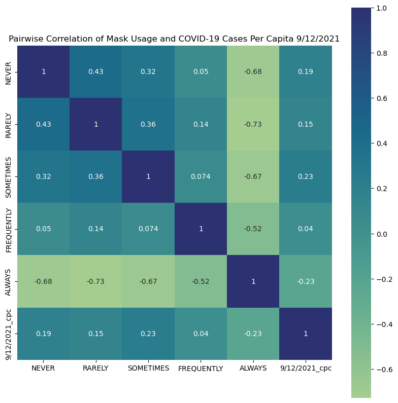

```python
plt.figure(figsize=(10, 10))
sns.heatmap(mask_data.corr(), annot=True, square=True, cmap="crest")
plt.title('Pairwise Correlation of Mask Usage and COVID-19 Cases Per Capita 9/12/2021')
```

## Creating a Preliminary COVID-19 Model

In this part I created a linear regression model that would predict the number of COVID-19 cases per capita given various COVID-19 safety protocols that had been implemented. Then, I investigated the bias, variance, and observational noise of this model in the next parts.

Despite the problems I found previously, I trained a linear regression model with an intercept term, using Scikit-learn, to predict the number of COVID-19 cases per capita for September 12, 2021 using county-wise mask usage data from `mask_data`. I used `train_test_split` to evaluate my model's RMSE on a held-out test set with 33% of the COVID-19 data; call the resulting splits `X_train`, `X_test`, `y_train`, and `y_test`.

```python
# Create train/test sets
X = mask_data[['NEVER', 'RARELY', 'SOMETIMES', 'FREQUENTLY', 'ALWAYS']]
y = mask_data['9/12/2021_cpc']
X_train, X_test, y_train, y_test = train_test_split(X, y, test_size=0.33, random_state=42)
#..., ..., ..., ...

# fit the linear model and make predictions
model = lm.LinearRegression()
model.fit(X_train, y_train)
y_pred = model.predict(X_test)


# compute RMSE on train and test sets
train_rmse_cpc = np.sqrt(np.mean((y_train - model.predict(X_train))**2))
test_rmse_cpc = np.sqrt(np.mean((y_test - y_pred)**2))

print(f'Train RMSE: {train_rmse_cpc:.3f}')
#...

train_rmse_cpc, test_rmse_cpc
```

```
Train RMSE: 0.036
```

```
(0.03552339478226883, 0.037954861477287)
```

To visualize the model performance from part the previous part, I made the following two visualizations:

(1) the predicted values vs. observed values on the test set

(2) the residuals plot. (Note: in multiple linear regression, the residual plot has predicted values vs. residuals)

Some notes:

- I used `plt.subplot` ([documentation](https://matplotlib.org/stable/gallery/subplots_axes_and_figures/subplots_demo.html)) so that I could view both visualizations side-by-side.

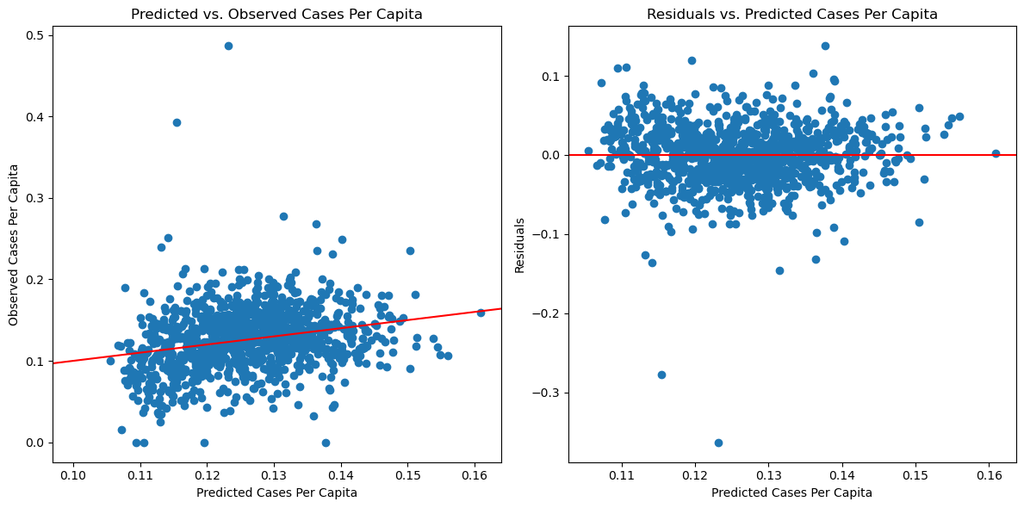

```python
plt.figure(figsize=(12,6))      # do not change this line

plt.subplot(121)                # do not change this line
# (1) predictions vs observations
plt.scatter(y_pred, y_test)
plt.axline([0.1,0.1], slope = 1, color="red", linestyle='-')
plt.xlabel('Predicted Cases Per Capita')
plt.ylabel('Observed Cases Per Capita')
plt.title('Predicted vs. Observed Cases Per Capita')
#...

plt.subplot(122)               # do not change this line
# (2) residual plot
plt.scatter(y_pred, [y_pred - y_test])
plt.axhline(y=0, color='r', linestyle='-')
plt.xlabel('Predicted Cases Per Capita')
plt.ylabel('Residuals')
plt.title('Residuals vs. Predicted Cases Per Capita') #...

plt.tight_layout()             # do not change this line
```

The model was decent because the y = y_hat fitted the residuals on both sides of the line. The residuals were also centered around 0, which meant that the model was not that biased.

## Performing Multicollinearity Analysis

In this part I performed an analysis that could reveal potential multicollinearity in my features, which is unideal. In particular, I used bootstrap to get $95\%$ confidence intervals on the fitted parameters.

### Yay! Bootstrap

```python
def bootstrap_sample(data, k):
    """
    Performs bootstrap sampling on data to obtain k samples of size n.

    Arguments:
        data - Dataset contained as a Pandas DataFrame
        k - Number of randomly drawn samples

    Returns:
        samples - List containing k Pandas DataFrames of size n each
                  corresponding to each sample
    """
    samples = []
    for x in range(k):
        samples.append(data.sample(n=len(data), replace=True))
    return samples

#...
bootstrap_sample(mask_data, 1)[0]
```

|  | NEVER | RARELY | SOMETIMES | FREQUENTLY | ALWAYS | 9/12/2021_cpc |
| --- | --- | --- | --- | --- | --- | --- |
| 2286 | 0.084 | 0.049 | 0.129 | 0.171 | 0.567 | 0.126824 |
| 1273 | 0.036 | 0.105 | 0.104 | 0.133 | 0.622 | 0.113733 |
| 1007 | 0.066 | 0.097 | 0.133 | 0.170 | 0.535 | 0.155318 |
| 1468 | 0.097 | 0.052 | 0.149 | 0.265 | 0.437 | 0.143628 |
| 625 | 0.056 | 0.056 | 0.105 | 0.183 | 0.599 | 0.133822 |
| ... | ... | ... | ... | ... | ... | ... |
| 3041 | 0.065 | 0.083 | 0.163 | 0.211 | 0.479 | 0.100894 |
| 440 | 0.075 | 0.088 | 0.125 | 0.112 | 0.600 | 0.126051 |
| 385 | 0.138 | 0.085 | 0.062 | 0.158 | 0.557 | 0.166782 |
| 1034 | 0.043 | 0.042 | 0.134 | 0.154 | 0.627 | 0.136443 |
| 38 | 0.093 | 0.119 | 0.141 | 0.179 | 0.469 | 0.136042 |

3141 rows × 6 columns

Using the function from the previous part, I did the following:

1. Generated 1000 bootstrapped samples from the original `mask_data` dataframe.
2. Used Scikit-learn to fit a linear regression model (with an intercept term) to use the mask usage features to predict the `9/12/2021_cpc` response.
3. Stored each of the 1000 trained models in the Python list `models`.

```python
np.random.seed(42)

datasets = bootstrap_sample(mask_data, 1000)
models = []
for dataset in datasets:
    X = dataset[['NEVER', 'RARELY', 'SOMETIMES', 'FREQUENTLY', 'ALWAYS']]
    y = dataset['9/12/2021_cpc']
    model = lm.LinearRegression()
    model.fit(X, y)
    models.append(model)

del datasets
```

### Confidence Interval

```python
def extract_coefs(models, include_intercept = True):
    """
    NOTE: This function has already been implemented. You do not need to modify this!

    Extracts coefficients of all the linear regression models in MODELS, and returns
    it as a NumPy array with one model's coefficients as each row.

    Arguments:
        models - Contains k sklearn LinearRegression models, each with p + 1 coefficients
        include_intercept - Whether to include intercept in returned coefficients

    Returns:
        coef_array - Coefficients of all k models, each with p + 1 coefficients (if intercept
                     enabled, otherwise p). Returned object is k x (p + 1) NumPy array.
    """
    coef_array = np.zeros(shape = (len(models), len(models[0].coef_) + 1))
    for i, m in enumerate(models):
        coef_array[i, 0] = m.intercept_
        coef_array[i, 1:] = m.coef_
    if include_intercept:
        return coef_array
    return coef_array[:, 1:]

def confidence_interval(coefs):
    """
    Calculates confidence intervals for each theta_i based on coefficients of
    bootstrapped models. Returns output as a list of confidence intervals.

    Arguments:
        coefs - Output of extract_coefs, a k x (p + 1) or k x p NumPy array containing
                coefficients of bootstrapped models

    Returns:
        cis - Confidence intervals of each parameter theta_i in the form of a
              list like this: [(0.5, 0.75), (0.2, 0.4), ...]
    """
    cis = []

    # FILL IN CODE BELOW
    for i in range(coefs.shape[1]):
        theta_i_values = coefs[:, i]
        theta_i_lower_ci, theta_i_upper_ci = np.percentile(theta_i_values, 2.5), np.percentile(theta_i_values, 97.5)
        cis.append((theta_i_lower_ci, theta_i_upper_ci))

    return cis

#...

# compute confidence intervals
model_coefs = extract_coefs(models)
cis = confidence_interval(model_coefs)

# pretty print in a table
display(Markdown('#### Confidence Intervals:'))
md_list = ["|parameter|lower|upper|",
           "----|----|----|"]
md_list += [fr"|$\theta_{i}$|{lci}|{uci}|" for i, (lci, uci) in enumerate(cis)]
display(Markdown('\n'.join(md_list)))
```

Confidence Intervals:

|  | parameter | lower | upper |  |
| --- | --- | --- | --- | --- |
|  | $\theta_0$ | -2.620072672904695 | 1.250787184226209 |  |
|  | $\theta_1$ | -1.0896828874135192 | 2.7983325852383625 |  |
|  | $\theta_2$ | -1.1461331540818134 | 2.744519025435909 |  |
|  | $\theta_3$ | -1.018294369222972 | 2.8436420433762413 |  |
|  | $\theta_4$ | -1.1582158941591831 | 2.7329392573407376 |  |
|  | $\theta_5$ | -1.1477854499077673 | 2.7195109052029283 |  |

## Performing Bias-Variance Analysis

In this part I performed an analysis that could estimate the bias and variance of our models, which could be helpful in modeling.

I used the same bootstrapped models contained in the Python list `models` to estimate our **model variance**. To do this, I remembered that the model variance on a data point is simply the variance of the predictions on that sample point. From the bias-variance decomposition, for a parametric model $\hat{Y}(x) = f_{\hat{\theta}}(x)$:

$$\text{model variance} = \mathrm{Var}(f_{\hat{\theta}}(x))$$

To investigate the variance in the test predictions, I sampled a particular data point $(x_i, y_i)$. Defining the **model risk** for this point as the mean square error over all possible fitted models:

$$\text{model risk} = \mathbb{E}\left[\left(y_i - f_{\hat{\theta}}(x_i)\right)^2\right]$$

Using the bootstrapped estimates `models`, I approximated the **ratio of model variance to model risk** for the datapoint $i = 100$, i.e., $(x_{100}, y_{100})$. I could interpret this ratio as the the proportion of the expected square error on the data point "captured" by the model variance. Since I used the bootstrap to create 1000 models, I generated 1000 predictions for the given $x_i$. Where `X` was the design matrix of mask features, and `y` was the `9/12/2021_cpc` response.

I then assigned `prop_var` to the computed, approximate ratio:

$$ \frac{\text{model variacne}}{\text{model risk}}=\frac{\mathrm{Var}\left(f_{\hat{\theta}}(x_{100})\right)}{\mathbb{E}\left[\left(y_{100} - f_{\hat{\theta}}(x_{100})\right)^2\right]} $$

```python
display("X_loc", X.loc[100], "X_iloc", X.iloc[100], "y_loc", y.loc[100], "y_iloc", y.iloc[100])
```

```
'X_loc'
```

|  | NEVER | RARELY | SOMETIMES | FREQUENTLY | ALWAYS |
| --- | --- | --- | --- | --- | --- |
| 100 | 0.111 | 0.089 | 0.167 | 0.089 | 0.544 |
| 100 | 0.111 | 0.089 | 0.167 | 0.089 | 0.544 |

```
'X_iloc'
```

```
NEVER         0.112
RARELY        0.064
SOMETIMES     0.128
FREQUENTLY    0.249
ALWAYS        0.447
Name: 2638, dtype: float64
```

```
'y_loc'
```

```
100    0.087892
100    0.087892
Name: 9/12/2021_cpc, dtype: float64
```

```
'y_iloc'
```

```
0.14731344005416647
```

```python
X.loc[100].iloc[0]
```

```
NEVER         0.111
RARELY        0.089
SOMETIMES     0.167
FREQUENTLY    0.089
ALWAYS        0.544
Name: 100, dtype: float64
```

```python
X_test_pt = X.loc[100].iloc[0]
y_test_pt = y.loc[100].iloc[0]
predictions = [model.predict(X_test_pt.values.reshape(1, -1)) for model in models]
predictions = np.array(predictions).flatten()
error_squared = [(y_test_pt - pred)**2 for pred in predictions]

preds_df = pd.DataFrame({'predictions': predictions, 'error_squared': error_squared})
prop_var = preds_df['predictions'].var() / preds_df['error_squared'].mean()


prop_var
```

```
0.0013182358857966859
```

The model variance is not the dominant term in the bias-variance decomposition. The model bias is the dominant term.

$$ \text{model risk} = \sigma^2 + (\text{model bias})^2 + \text{model variance} $$

where $\sigma^2$ was the observation variance, or "irreducible error".

Then, I calculated the average variance and average mean square error across 250 randomly sampled $(x_i, y_i)$ points. In other words, I estimated the following quantities across all $x_i$ and $y_i$ in `X_sample` and `y_sample`:

$$ \frac{1}{250} \sum_{i=1}^{250} \mathrm{Var}\left(f_{\hat{\theta}}(x_i)\right) $$

and

$$ \frac{1}{250} \sum_{i=1}^{250} \mathbb{E}\left[\left(y_i - f_{\hat{\theta}}(x_i)\right)^2\right] $$

```python
np.random.seed(42)

X_sample = X.sample(250)         # generate 250 x_i
y_sample = y.loc[X_sample.index] # ...and select the corresponding y_i

avg_var, avg_mse = 0, 0

for i in range(250):
    X_test_pt = X_sample.reset_index().loc[i].values[1:]
    y_test_pt = y_sample.reset_index().loc[i].values[1]
    predictions = [model.predict(X_test_pt.reshape(1, -1)) for model in models]
    predictions = np.array(predictions).flatten()
    error_squared = [(y_test_pt - pred)**2 for pred in predictions]
    avg_var += np.var(predictions)
    avg_mse += sum(error_squared) / len(models)

avg_var /= 250
avg_mse /= 250

avg_var, avg_mse
```

```
(2.8248352750171107e-06, 0.0016658308894561505)
```

From the observations, I believed I could reduce the mean square error by reducing the model bias. I could do this by adding more features to the model...